# STATS418_HW3

Yujia Hao 504702886

5/20/2017

I got the data from UCI Machine Learning Repository website. The dataset includes 48842 instances, 14 attributes, and the charactereistics of attributes are categorical and integer. I chose class, which includes the income less than 50K and more than 50K, as my binary variable to study in this report. First of all, I downloaded the original train and test dataset, and merged them to achieve a dataset that contains at least 10000 positive and 10000 negative examples. Then, I cleaned the data by skipping the null values, and look for the dimension of income less than 50K and more than 50K, which are 37155, 11687 respectively.

```r
temp <- tempfile()
download.file("https://archive.ics.uci.edu/ml/machine-learning-databases/adult/adult.data",temp)
mydata <- read.csv(temp, fill = TRUE, header=FALSE,skipNul = TRUE)
unlink(temp)
temp2 <- tempfile()
download.file("https://archive.ics.uci.edu/ml/machine-learning-databases/adult/adult.test",temp2)
mydata2 <- read.csv(temp2, skip = 1, fill = TRUE, header=FALSE,skipNul = TRUE)
unlink(temp2)
mydat <- rbind(mydata,mydata2)
values <- c("age","workclass","fnlwgt", "education", "education_num", "marital_status", "occupation", "relationship", "race", "sex", "capital_gain", "capital_loss", "hours_per_week", "native_country", "class")
names(mydat) <- values
head(mydat)
```

```
##   age         workclass fnlwgt  education education_num
## 1  39         State-gov  77516  Bachelors            13
## 2  50  Self-emp-not-inc  83311  Bachelors            13
## 3  38           Private 215646    HS-grad             9
## 4  53           Private 234721       11th             7
## 5  28           Private 338409  Bachelors            13
## 6  37           Private 284582    Masters            14
##        marital_status         occupation   relationship   race     sex
## 1       Never-married       Adm-clerical  Not-in-family  White    Male
## 2  Married-civ-spouse    Exec-managerial        Husband  White    Male
## 3            Divorced  Handlers-cleaners  Not-in-family  White    Male
## 4  Married-civ-spouse  Handlers-cleaners        Husband  Black    Male
## 5  Married-civ-spouse     Prof-specialty           Wife  Black  Female
## 6  Married-civ-spouse    Exec-managerial           Wife  White  Female
##   capital_gain capital_loss hours_per_week native_country  class
## 1         2174            0             40  United-States  <=50K
## 2            0            0             13  United-States  <=50K
## 3            0            0             40  United-States  <=50K
## 4            0            0             40  United-States  <=50K
## 5            0            0             40           Cuba  <=50K
## 6            0            0             40  United-States  <=50K
```

```r
library(dplyr)
mydat$class <- as.character(mydat$class)
mydat$class[mydat$class == " <=50K."] <- " <=50K"
mydat$class[mydat$class == " >50K."] <- " >50K"
mydat$class <- as.factor(mydat$class)
A <- filter(mydat, mydat$class == ' <=50K')
B <- filter(mydat, mydat$class == ' >50K')
# The dimension of the income less than 50K
dim(A)
```

```
## [1] 37155    15
```

```r
# The dimension of the income more than 50K
dim(B)
```

```
## [1] 11687    15
```

## Logistic Regression with various implementations.

I split the dataset into train and test by ratio of 0.6. Because the dataset includes both categorical and integer variables, I cannot use model.matrix directly to apply all the variables on class. Therefore, I model.matrix all the categorical variables, and then use as.matrix to combine all the variables to get X_train and X_test. Then, I used cross-validation to select lambda. The best lambda should be the minimum, which is 0.0004934503, and the AUC is 0.9061829.

```r
for (i in 1:15) {
  print(class(mydat[,i]))
}
```

```
## [1] "integer"
## [1] "factor"
## [1] "integer"
## [1] "factor"
## [1] "integer"
## [1] "factor"
## [1] "factor"
## [1] "factor"
## [1] "factor"
## [1] "factor"
## [1] "integer"
## [1] "integer"
## [1] "integer"
## [1] "factor"
## [1] "factor"
```

```r
library(readr)
library(glmnet)
library(ROCR)
```

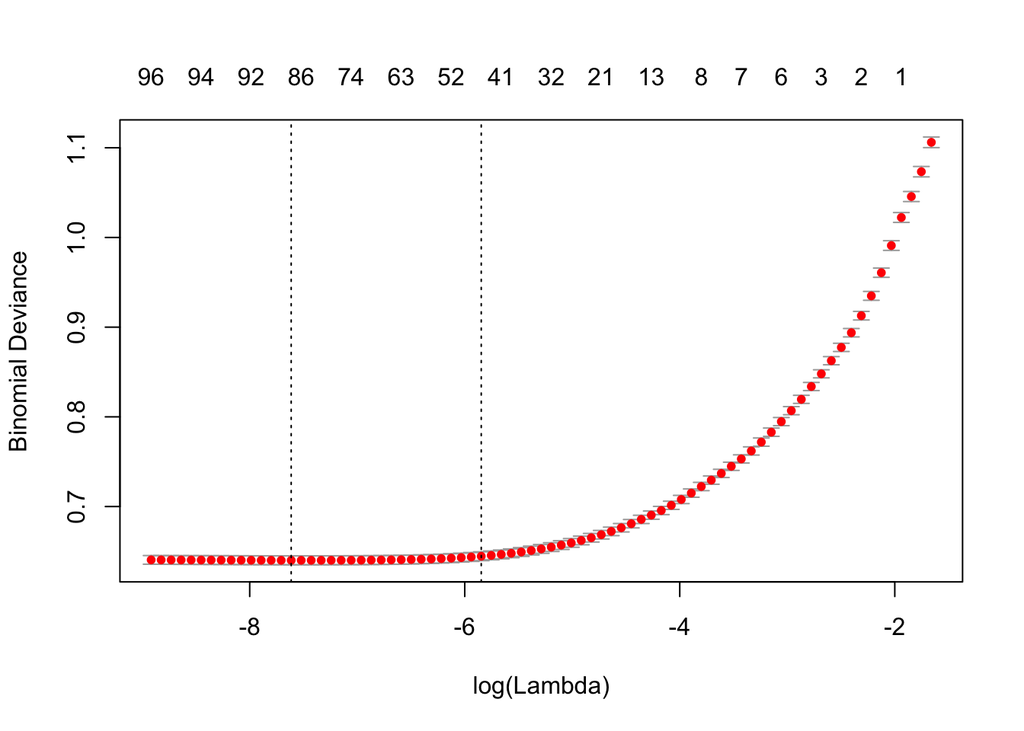

```r
set.seed(123)
N <- nrow(mydat)
idx <- sample(1:N, 0.6*N)
d_train <- mydat[idx,]
d_test <- mydat[-idx,]

xfactors <- model.matrix(class ~ workclass + education + marital_status + occupation + relationship + race + sex + native_country, data = d_train)[, -1]
x <- as.matrix(data.frame(d_train$age, d_train$fnlwgt, d_train$education_num, d_train$capital_gain, d_train$capital_loss, d_train$hours_per_week, xfactors))

xfactor <-  model.matrix(class ~ workclass + education + marital_status + occupation + relationship + race + sex + native_country, data = d_test)[, -1]
x2 <- as.matrix(data.frame(d_test$age, d_test$fnlwgt, d_test$education_num, d_test$capital_gain, d_test$capital_loss, d_test$hours_per_week, xfactor))

cv.md <- cv.glmnet(x, d_train$class, alpha=1, family = "binomial")
plot(cv.md)
```

```r
(best.lambda <- cv.md$lambda.min)
```

```
## [1] 0.0004934503
```

```r
system.time({
  md <- glmnet( x, d_train$class, family = "binomial", lambda = 0.0004934503)
})
```

```
##    user  system elapsed
##   2.342   0.019   2.374
```

```r
phat <- predict(md, newx = x2, type = "response")
rocr_pred <- prediction(phat, d_test$class)
performance(rocr_pred, "auc")@y.values[[1]]
```

```
## [1] 0.9061829
```

The ROC curve is as following. The ROC curve is created by plotting the true positive rate against the false positive rate at various threshold settings. The true positive rate measures the proportion of cases were positive and predicted positive. The false positive rate measures the proportion of cases were negative but predicted positive. In this situation, TP represents the income that more than 50K and predicted more than 50K, the FP represents the income that less than 50K but predicted as more than 50K, the tradeoff is when more people’s income is more than 50K, the less people’s income is less than 50K under the situation when we predict people’s income is more than 50K.

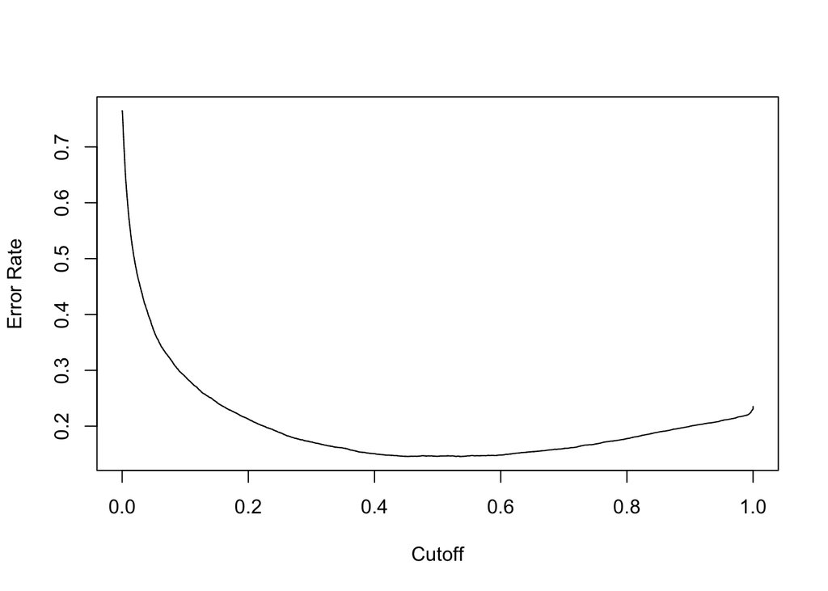

```r
rocr_obj <- prediction(phat, d_test$class)
plot(performance(rocr_obj, "err"))
```

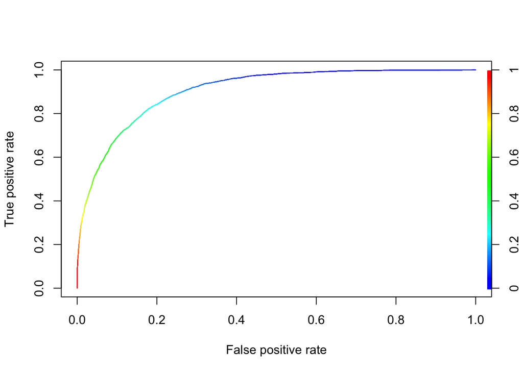

```r
plot(performance(rocr_obj, "tpr", "fpr"), colorize=TRUE)
```

I also tried h2o method, and the AUC is 0.909504.

```r
write.csv(mydat, file = "mydat")
library(h2o)
h2o.init(nthreads=-1)
```

```
##
## H2O is not running yet, starting it now...
##
## Note:  In case of errors look at the following log files:
##     /var/folders/vw/mp1by2lj4pl_51mddptf1ps00000gn/T//RtmphzHPYj/h2o_haoyujia_started_from_r.out
##     /var/folders/vw/mp1by2lj4pl_51mddptf1ps00000gn/T//RtmphzHPYj/h2o_haoyujia_started_from_r.err
##
##
## Starting H2O JVM and connecting: .. Connection successful!
##
## R is connected to the H2O cluster:
##     H2O cluster uptime:         3 seconds 276 milliseconds
##     H2O cluster version:        3.10.4.6
##     H2O cluster version age:    27 days
##     H2O cluster name:           H2O_started_from_R_haoyujia_srl771
##     H2O cluster total nodes:    1
##     H2O cluster total memory:   0.12 GB
##     H2O cluster total cores:    4
##     H2O cluster allowed cores:  4
##     H2O cluster healthy:        TRUE
##     H2O Connection ip:          localhost
##     H2O Connection port:        54321
##     H2O Connection proxy:       NA
##     H2O Internal Security:      FALSE
##     R Version:                  R version 3.4.0 (2017-04-21)
```

```r
dx <- h2o.importFile("mydat")
dx_split <- h2o.splitFrame(dx, ratios = 0.6, seed = 123)
dx_train <- dx_split[[1]]
dx_test <- dx_split[[2]]


Xnames <- names(dx_train)[which(names(dx_train)!="class")]

system.time({
  md <- h2o.glm(x = Xnames, y = "class", training_frame = dx_train,
                family = "binomial", alpha = 1, lambda = 0)
})
```

```
##    user  system elapsed
##   0.222   0.014   2.705
```

```r
h2o.auc(h2o.performance(md, dx_test))
```

```
## [1] 0.9041802
```

```r
md
```

```
## Model Details:
## ==============
##
## H2OBinomialModel: glm
## Model ID:  GLM_model_R_1495624907286_1
## GLM Model: summary
##     family  link regularization number_of_predictors_total
## 1 binomial logit           None                        101
##   number_of_active_predictors number_of_iterations  training_frame
## 1                         101                    7 RTMP_sid_96ac_2
##
## Coefficients: glm coefficients
##                      names coefficients standardized_coefficients
## 1                Intercept   -29.138773                  7.410526
## 2 native_country. Cambodia     1.217117                  1.217117
## 3   native_country. Canada     0.684150                  0.684150
## 4    native_country. China    -0.468070                 -0.468070
## 5 native_country. Columbia    -4.071073                 -4.071073
##
## ---
##              names coefficients standardized_coefficients
## 97             age     0.026455                  0.362166
## 98          fnlwgt     0.000001                  0.080150
## 99   education_num     3.358605                  8.620497
## 100   capital_gain     0.000333                  2.477596
## 101   capital_loss     0.000670                  0.269908
## 102 hours_per_week     0.027303                  0.337826
##
## H2OBinomialMetrics: glm
## ** Reported on training data. **
##
## MSE:  0.09996274
## RMSE:  0.3161688
## LogLoss:  0.31264
## Mean Per-Class Error:  0.1903308
## AUC:  0.909504
## Gini:  0.819008
## R^2:  0.4475087
## Null Deviance:  32159.18
## Residual Deviance:  18353.22
## AIC:  18557.22
##
## Confusion Matrix (vertical: actual; across: predicted) for F1-optimal threshold:
##         <=50K  >50K    Error         Rate
##  <=50K  19688  2702 0.120679  =2702/22390
##  >50K    1810  5152 0.259983   =1810/6962
## Totals  21498  7854 0.153720  =4512/29352
##
## Maximum Metrics: Maximum metrics at their respective thresholds
##                         metric threshold    value idx
## 1                       max f1  0.358465 0.695464 212
## 2                       max f2  0.135308 0.789935 309
## 3                 max f0point5  0.555009 0.710384 143
## 4                 max accuracy  0.486880 0.855172 164
## 5                max precision  0.993832 0.993617   3
## 6                   max recall  0.000952 1.000000 398
## 7              max specificity  0.999808 0.999866   0
## 8             max absolute_mcc  0.400878 0.595794 196
## 9   max min_per_class_accuracy  0.270223 0.822896 249
## 10 max mean_per_class_accuracy  0.229085 0.825571 267
##
## Gains/Lift Table: Extract with `h2o.gainsLift(<model>, <data>)` or `h2o.gainsLift(<model>, valid=<T/F>, xval=<T/F>)`
```

## Random Forest with various implementations.

number of trees = 50, the depth of the trees = 2000 , the parameter governing the number of columns used in each split = 2. The ROC curve is as following.

```r
library(randomForest)
set.seed(123)
dim(d_train)
```

```
## [1] 29305    15
```

```r
dim(d_test)
```

```
## [1] 19537    15
```

```r
md <- randomForest(class ~ ., data = d_train, ntree = 50, nodesize = 2000, mtry = 2)
md
```

```
##
## Call:
##  randomForest(formula = class ~ ., data = d_train, ntree = 50,      nodesize = 2000, mtry = 2)
##                Type of random forest: classification
##                      Number of trees: 50
## No. of variables tried at each split: 2
##
##         OOB estimate of  error rate: 16.62%
## Confusion matrix:
##         <=50K  >50K class.error
##  <=50K  21587   628  0.02826919
##  >50K    4243  2847  0.59844852
```

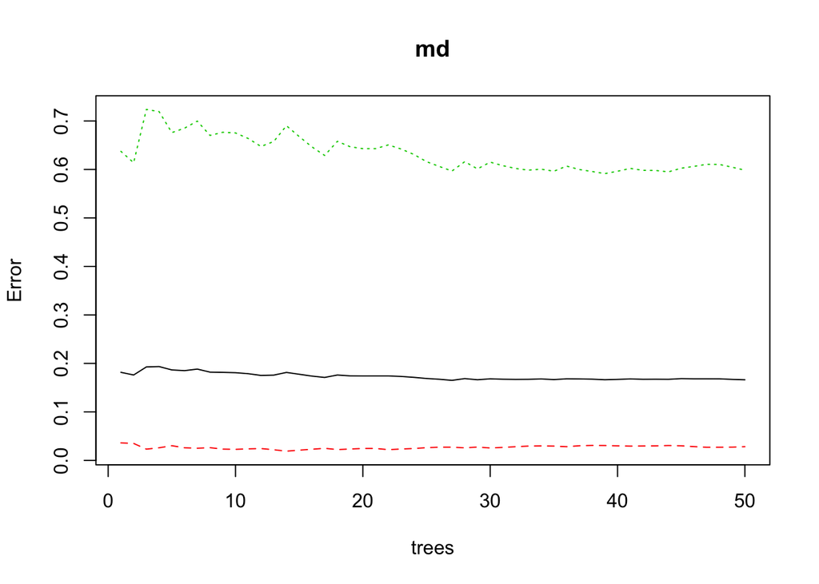

```r
plot(md)
```

```r
phat <- predict(md, d_test, type = "prob")[," >50K"]
table(ifelse(phat>0.5,1,0), d_test$class)
```

```
##
##      <=50K  >50K
##   0  14524  2764
##   1    416  1833
```

```r
(14524+1833)/19537
```

```
## [1] 0.8372319
```

```r
rocr_pred <- prediction(phat, d_test$class)
performance(rocr_pred, "auc")@y.values[[1]]
```

```
## [1] 0.8729639
```

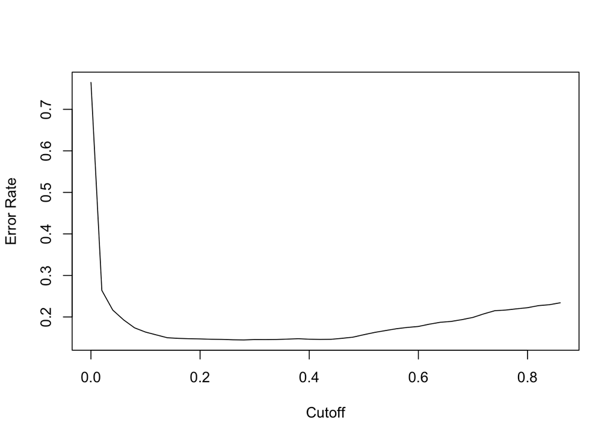

```r
rocr_obj <- prediction(phat, d_test$class)
plot(performance(rocr_obj, "err"))
```

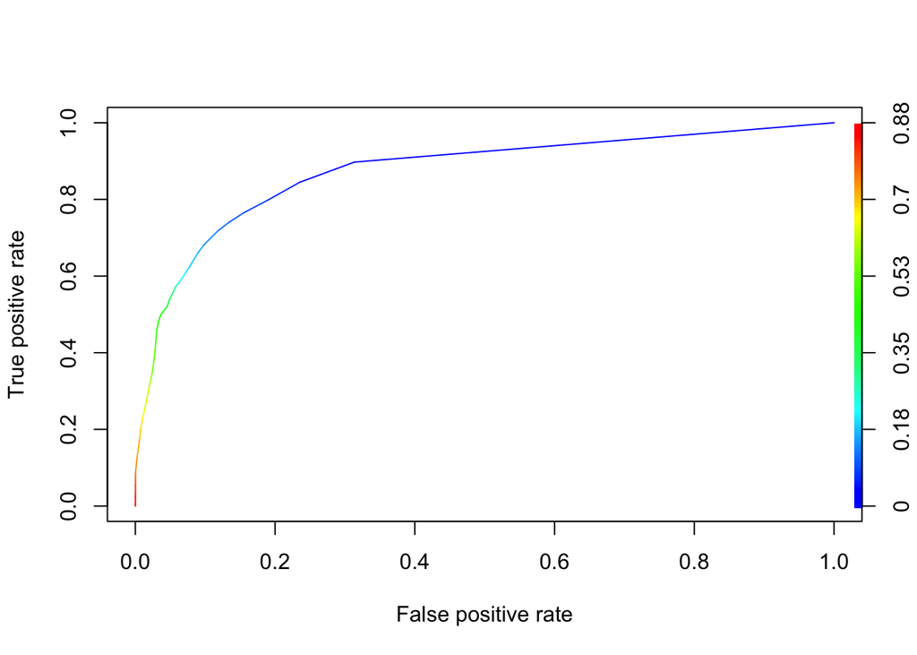

```r
plot(performance(rocr_obj, "tpr", "fpr"), colorize=TRUE)
```

Then, I tried number of trees = 75, the depth of the trees = 2000 , the parameter governing the number of columns used in each split = 2, which means I only changed the number of trees from 50 to 75, and keep other 2 parameters the same. I found the OOB was decreased, and AUC was slightly increased. The ROC curve is as following.

```r
library(randomForest)
set.seed(123)
dim(d_train)
```

```
## [1] 29305    15
```

```r
dim(d_test)
```

```
## [1] 19537    15
```

```r
md <- randomForest(class ~ ., data = d_train, ntree = 75, nodesize = 2000, mtry = 2)
md
```

```
##
## Call:
##  randomForest(formula = class ~ ., data = d_train, ntree = 75,      nodesize = 2000, mtry = 2)
##                Type of random forest: classification
##                      Number of trees: 75
## No. of variables tried at each split: 2
##
##         OOB estimate of  error rate: 16.41%
## Confusion matrix:
##         <=50K  >50K class.error
##  <=50K  21528   687  0.03092505
##  >50K    4121  2969  0.58124118
```

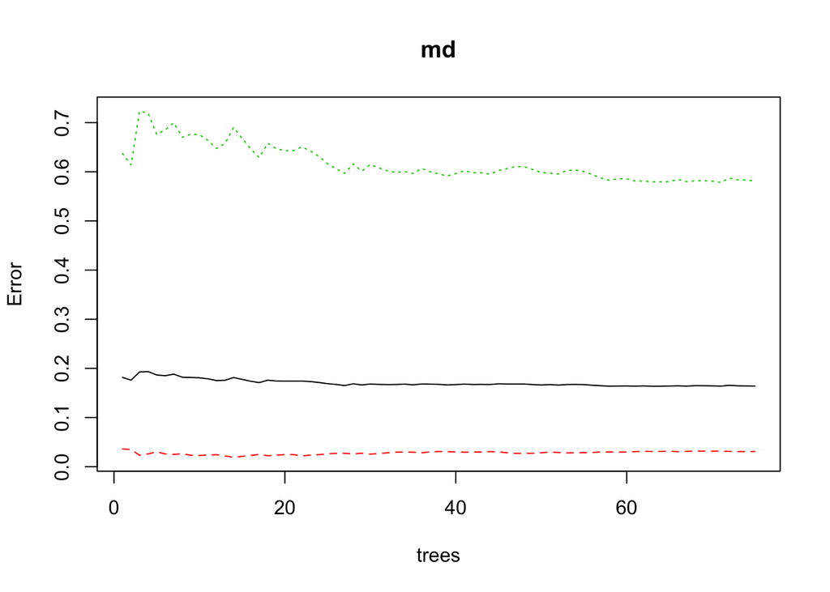

```r
plot(md)
```

```r
phat <- predict(md, d_test, type = "prob")[," >50K"]
table(ifelse(phat>0.5,1,0), d_test$class)
```

```
##
##      <=50K  >50K
##   0  14492  2632
##   1    448  1965
```

```r
(14492+1965)/19537
```

```
## [1] 0.8423504
```

```r
rocr_pred <- prediction(phat, d_test$class)
performance(rocr_pred, "auc")@y.values[[1]]
```

```
## [1] 0.8754117
```

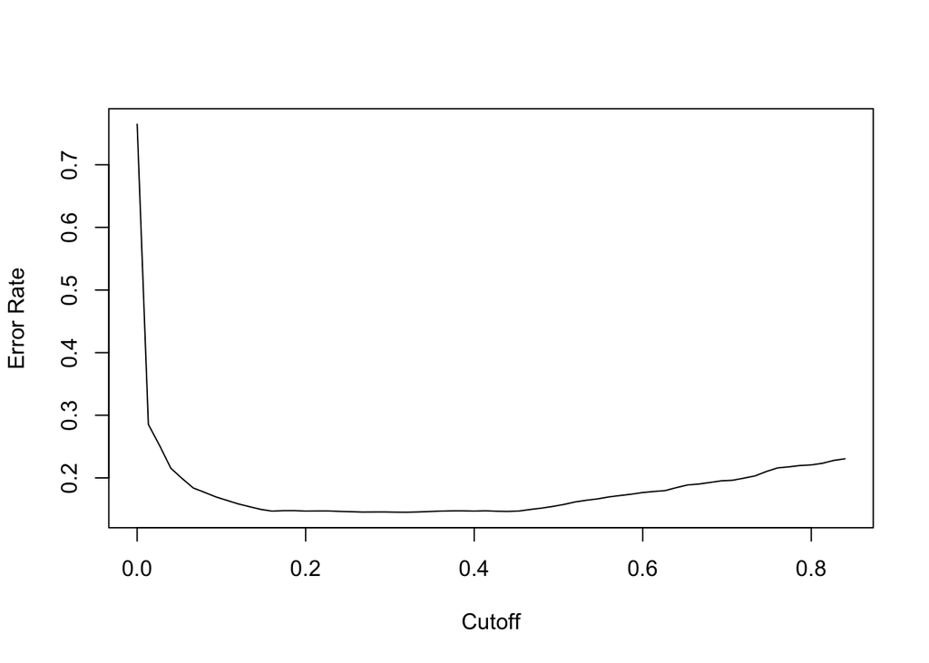

```r
rocr_obj <- prediction(phat, d_test$class)
plot(performance(rocr_obj, "err"))
```

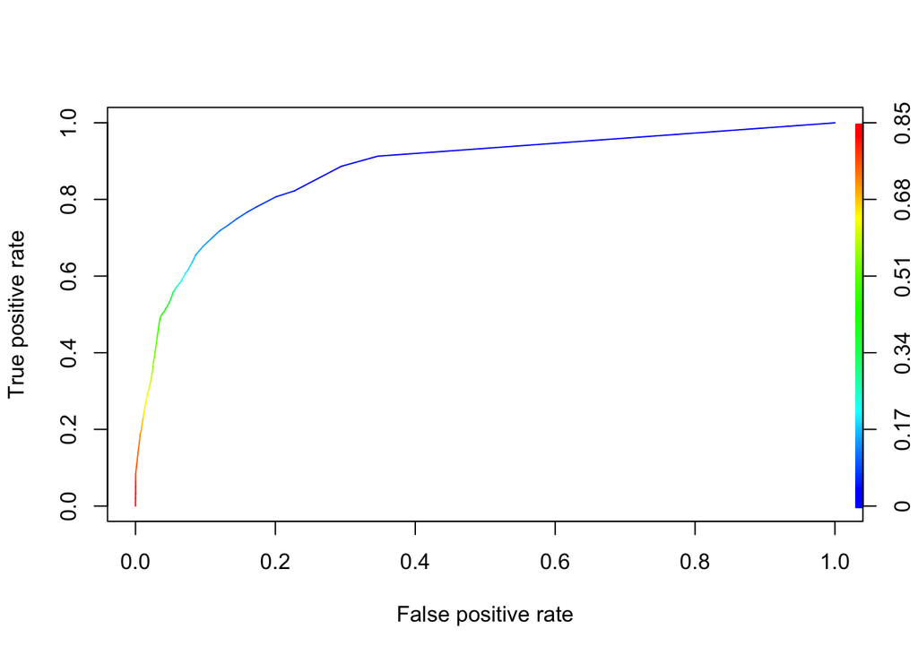

```r
plot(performance(rocr_obj, "tpr", "fpr"), colorize=TRUE)
```

```r
library(randomForest)
set.seed(123)
dim(d_train)
```

```
## [1] 29305    15
```

```r
dim(d_test)
```

```
## [1] 19537    15
```

```r
md <- randomForest(class ~ ., data = d_train, ntree = 100,  nodesize = 5000, mtry = 2)
md
```

```
##
## Call:
##  randomForest(formula = class ~ ., data = d_train, ntree = 100,      nodesize = 5000, mtry = 2)
##                Type of random forest: classification
##                      Number of trees: 100
## No. of variables tried at each split: 2
##
##         OOB estimate of  error rate: 21.24%
## Confusion matrix:
##         <=50K  >50K class.error
##  <=50K  22093   122 0.005491785
##  >50K    6102   988 0.860648801
```

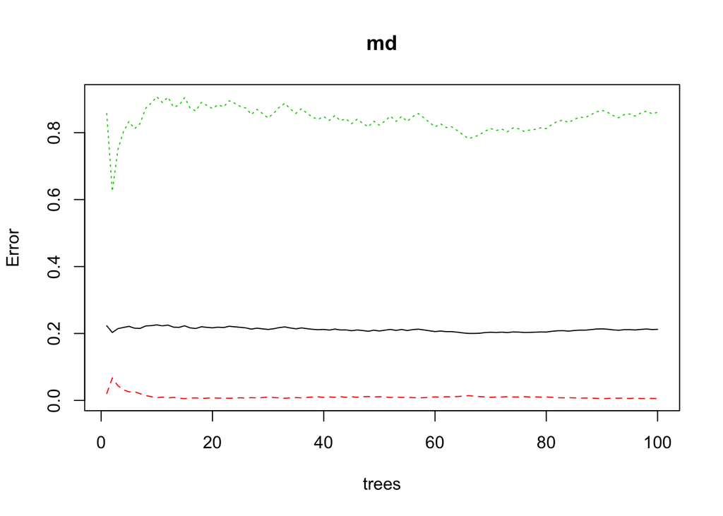

```r
plot(md)
```

```r
phat <- predict(md, d_test, type = "prob")[," >50K"]
table(ifelse(phat>0.5,1,0), d_test$class)
```

```
##
##      <=50K  >50K
##   0  14936  4228
##   1      4   369
```

```r
(14936+369)/19537
```

```
## [1] 0.7833854
```

```r
rocr_pred <- prediction(phat, d_test$class)
performance(rocr_pred, "auc")@y.values[[1]]
```

```
## [1] 0.886543
```

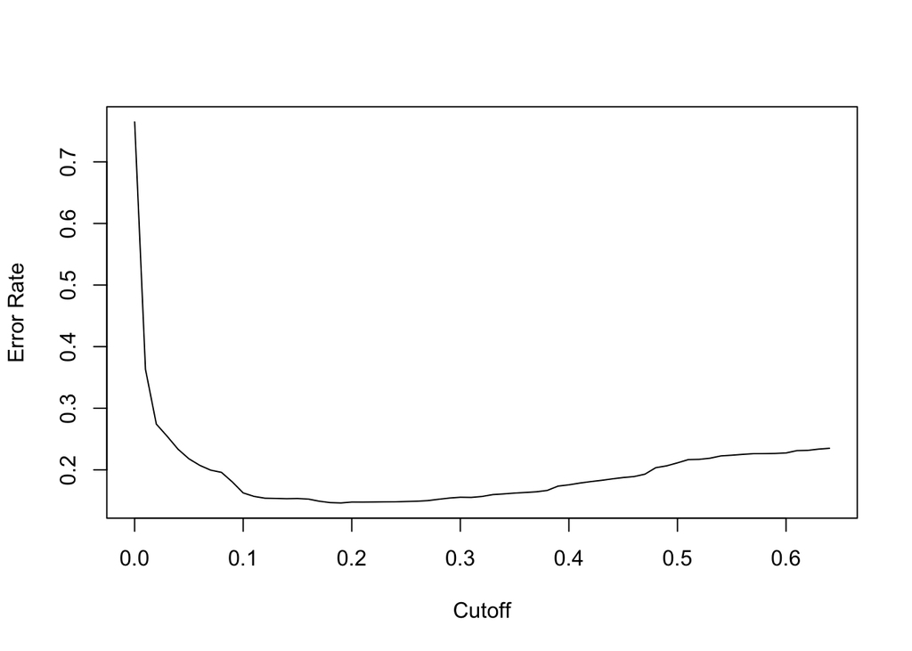

```r
rocr_obj <- prediction(phat, d_test$class)
plot(performance(rocr_obj, "err"))
```

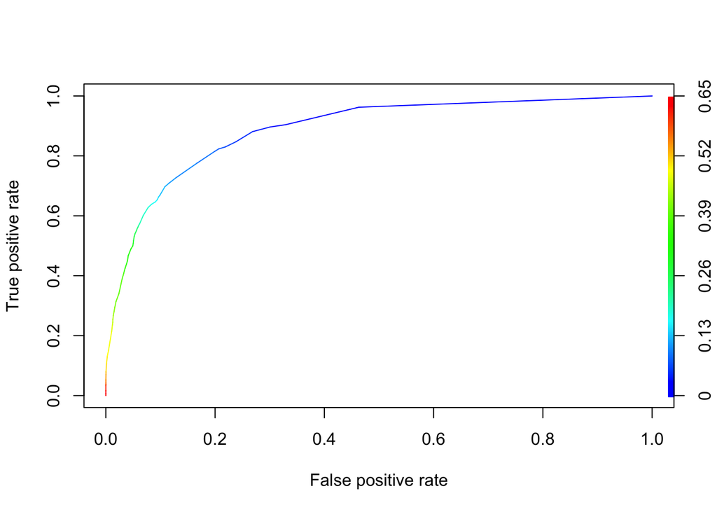

```r
plot(performance(rocr_obj, "tpr", "fpr"), colorize=TRUE)
```

Then, I tried xgboost method to do random forest, and tried various numbers of trees and tune the depth of the trees and the parameter governing the number of columns used in each split. I found when I increase the depth of the trees, and increased the number of trees, and increased the parameter governing the numebr of columns used in each split, the AUC increased a lot. With the large AUC, it may cause overfit.

```r
library(readr)
library(xgboost)
library(ROCR)



system.time({
  n_proc <- parallel::detectCores()
  md <- xgboost(data = x, label = ifelse(d_train$class==' >50K',1,0),
                nthread = n_proc, nround = 1, max_depth = 10,
                num_parallel_tree = 50, subsample = 0.5,
                colsample_bytree = 0.2,
                save_period = NULL)
})
```

```
##    user  system elapsed
##   6.154   0.076   1.750
```

```r
phat <- predict(md, newdata = x2)

rocr_pred <- prediction(phat, d_test$class)
performance(rocr_pred, "auc")@y.values[[1]]
```

```
## [1] 0.8594661
```

```r
library(readr)
library(xgboost)
library(ROCR)

system.time({
  n_proc <- parallel::detectCores()
  md <- xgboost(data = x, label = ifelse(d_train$class==' >50K',1,0),
                nthread = n_proc, nround = 1, max_depth = 20,
                num_parallel_tree = 500, subsample = 0.5,
                colsample_bytree = 0.5,
                save_period = NULL)
})
```

```
##    user  system elapsed
## 203.613   1.220  57.105
```

```r
phat <- predict(md, newdata = x2)

rocr_pred <- prediction(phat, d_test$class)
performance(rocr_pred, "auc")@y.values[[1]]
```

```
## [1] 0.9129719
```

```r
library(h2o)

h2o.init(nthreads=-1)
```

```
##  Connection successful!
##
## R is connected to the H2O cluster:
##     H2O cluster uptime:         1 minutes 19 seconds
##     H2O cluster version:        3.10.4.6
##     H2O cluster version age:    27 days
##     H2O cluster name:           H2O_started_from_R_haoyujia_srl771
##     H2O cluster total nodes:    1
##     H2O cluster total memory:   0.03 GB
##     H2O cluster total cores:    4
##     H2O cluster allowed cores:  4
##     H2O cluster healthy:        TRUE
##     H2O Connection ip:          localhost
##     H2O Connection port:        54321
##     H2O Connection proxy:       NA
##     H2O Internal Security:      FALSE
##     R Version:                  R version 3.4.0 (2017-04-21)
```

```r
dx <- h2o.importFile("mydat")
dx_split <- h2o.splitFrame(dx, ratios = 0.6, seed = 123)
dx_train <- dx_split[[1]]
dx_test <- dx_split[[2]]


Xnames <- names(dx_train)[which(names(dx_train)!="class")]

system.time({
  md <- h2o.randomForest(x = Xnames, y = "class", training_frame = dx_train, ntrees = 50)
})
```

```
##    user  system elapsed
##   0.241   0.008   7.480
```

```r
h2o.auc(h2o.performance(md, dx_test))
```

```
## [1] 0.9115939
```

```r
md
```

```
## Model Details:
## ==============
##
## H2OBinomialModel: drf
## Model ID:  DRF_model_R_1495624907286_4
## Model Summary:
##   number_of_trees number_of_internal_trees model_size_in_bytes min_depth
## 1              50                       50             1378071        20
##   max_depth mean_depth min_leaves max_leaves mean_leaves
## 1        20   20.00000       1577       2365  2029.54000
##
##
## H2OBinomialMetrics: drf
## ** Reported on training data. **
## ** Metrics reported on Out-Of-Bag training samples **
##
## MSE:  0.09482672
## RMSE:  0.3079395
## LogLoss:  0.3503489
## Mean Per-Class Error:  0.1879875
## AUC:  0.9133154
## Gini:  0.8266308
##
## Confusion Matrix (vertical: actual; across: predicted) for F1-optimal threshold:
##         <=50K  >50K    Error         Rate
##  <=50K  20047  2343 0.104645  =2343/22390
##  >50K    1889  5073 0.271330   =1889/6962
## Totals  21936  7416 0.144181  =4232/29352
##
## Maximum Metrics: Maximum metrics at their respective thresholds
##                         metric threshold    value idx
## 1                       max f1  0.395231 0.705661 207
## 2                       max f2  0.199734 0.786430 290
## 3                 max f0point5  0.617211 0.746144 123
## 4                 max accuracy  0.497850 0.866278 166
## 5                max precision  0.985905 0.996094   4
## 6                   max recall  0.000001 1.000000 399
## 7              max specificity  0.999943 0.999866   0
## 8             max absolute_mcc  0.442886 0.613816 187
## 9   max min_per_class_accuracy  0.292275 0.827923 251
## 10 max mean_per_class_accuracy  0.259965 0.828922 266
##
## Gains/Lift Table: Extract with `h2o.gainsLift(<model>, <data>)` or `h2o.gainsLift(<model>, valid=<T/F>, xval=<T/F>)`
```

## Generalized Boosted Regression Models

Firstly, I used xgboost package, and I used the inbuilt xgb,cv function to calculate the best nround for this model, the best interation was indicated to 38. Then, I used nrounds = 38 to construct generalized boosted regression model, and early stop at 10. I tried 2 different method of determine parameters, the AUC was almost the same, around 0.926.

```r
library(xgboost)
set.seed(123)

dxgb_train <- xgb.DMatrix(data = x, label = ifelse(d_train$class==' >50K',1,0))
dxgb_test <- xgb.DMatrix(data = x2, label = ifelse(d_test$class==' >50K',1,0))

params <- list(booster = "gbtree", objective = "binary:logistic", eta=0.3, gamma=0, max_depth=6, min_child_weight=1, subsample=1, colsample_bytree=1)

xgbcv <- xgb.cv( params = params, data = dxgb_train, nrounds = 100, nfold = 5, showsd = T, stratified = T, print.every.n = 10, early.stop.round = 10, maximize = F)
```

[output not shown]

```r
system.time({
  n_proc <- parallel::detectCores()
  md <- xgb.train(data = dxgb_train, nthread = n_proc, objective = "binary:logistic",
                  nround = 38, max_depth = 6, eta = 0.3)
})
```

```
##    user  system elapsed
##   8.729   0.031   2.416
```

```r
phat <- predict(md, newdata = dxgb_test)

rocr_pred <- prediction(phat, d_test$class)
performance(rocr_pred, "auc")@y.values[[1]]
```

```
## [1] 0.9261468
```

```r
xgb1 <- xgb.train (params = params, data = dxgb_train, nrounds = 38, watchlist = list(val=dxgb_test,train=dxgb_train), print.every.n = 10, early.stop.round = 10, maximize = F , eval_metric = "error")
```

```
## Multiple eval metrics are present. Will use train_error for early stopping.
## Will train until train_error hasn't improved in 10 rounds.
##
```

```r
phat <- predict(xgb1, newdata = dxgb_test)

rocr_pred <- prediction(phat, d_test$class)
performance(rocr_pred, "auc")@y.values[[1]]
```

```
## [1] 0.9259165
```

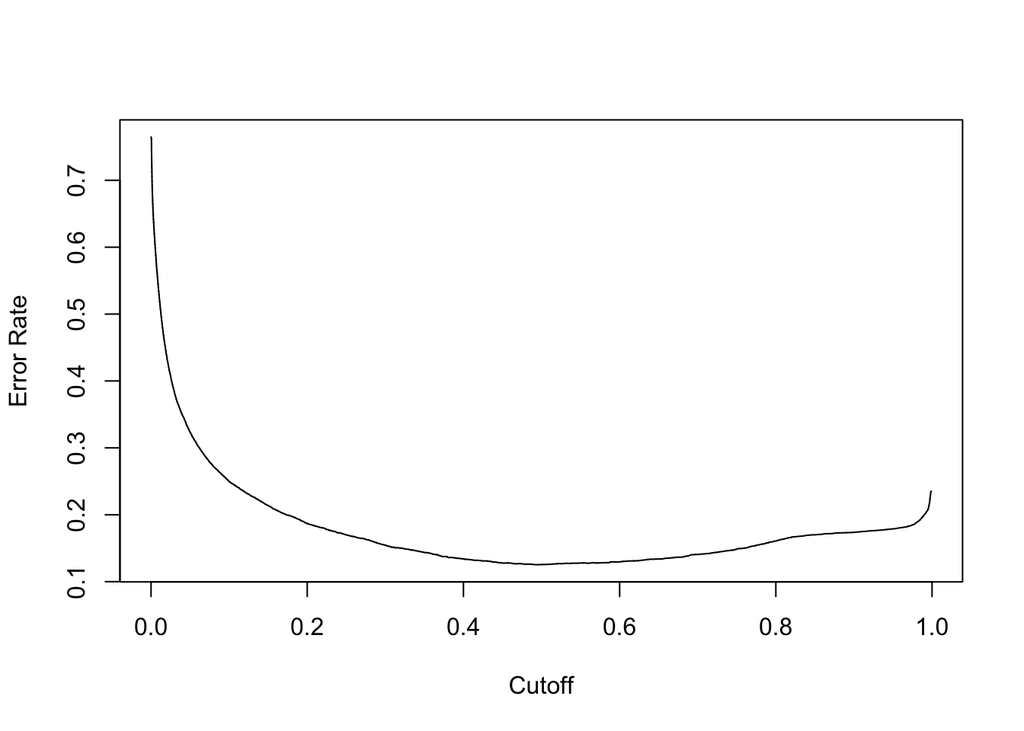

```r
rocr_obj <- prediction(phat, d_test$class)
plot(performance(rocr_obj, "err"))
```

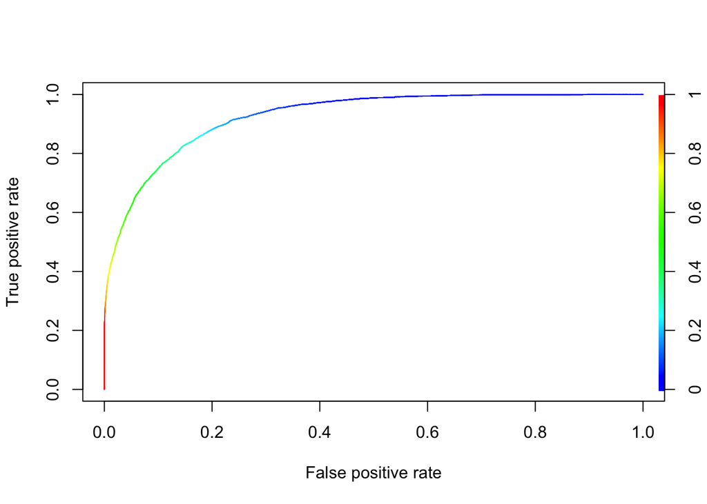

```r
plot(performance(rocr_obj, "tpr", "fpr"), colorize=TRUE)
```

```r
library(h2o)

h2o.init(nthreads=-1)
```

```
##  Connection successful!
##
## R is connected to the H2O cluster:
##     H2O cluster uptime:         1 minutes 53 seconds
##     H2O cluster version:        3.10.4.6
##     H2O cluster version age:    27 days
##     H2O cluster name:           H2O_started_from_R_haoyujia_srl771
##     H2O cluster total nodes:    1
##     H2O cluster total memory:   0.09 GB
##     H2O cluster total cores:    4
##     H2O cluster allowed cores:  4
##     H2O cluster healthy:        TRUE
##     H2O Connection ip:          localhost
##     H2O Connection port:        54321
##     H2O Connection proxy:       NA
##     H2O Internal Security:      FALSE
##     R Version:                  R version 3.4.0 (2017-04-21)
```

```r
dx <- h2o.importFile("mydat")
dx_split <- h2o.splitFrame(dx, ratios = 0.6, seed = 123)
dx_train <- dx_split[[1]]
dx_test <- dx_split[[2]]


Xnames <- names(dx_train)[which(names(dx_train)!="class")]

system.time({
  md <- h2o.gbm(x = Xnames, y = "class", training_frame = dx_train, distribution = "bernoulli",
                ntrees = 50, max_depth = 6, learn_rate = 0.1,
                nbins = 100, seed = 123)
})
```

```
##    user  system elapsed
##   0.171   0.010   5.598
```

```r
h2o.auc(h2o.performance(md, dx_test))
```

```
## [1] 0.922389
```

```r
md
```

```
## Model Details:
## ==============
##
## H2OBinomialModel: gbm
## Model ID:  GBM_model_R_1495624907286_37
## Model Summary:
##   number_of_trees number_of_internal_trees model_size_in_bytes min_depth
## 1              50                       50               95126         6
##   max_depth mean_depth min_leaves max_leaves mean_leaves
## 1         6    6.00000         37         58    48.78000
##
##
## H2OBinomialMetrics: gbm
## ** Reported on training data. **
##
## MSE:  0.08038481
## RMSE:  0.2835222
## LogLoss:  0.2598094
## Mean Per-Class Error:  0.1513042
## AUC:  0.9411909
## Gini:  0.8823818
##
## Confusion Matrix (vertical: actual; across: predicted) for F1-optimal threshold:
##         <=50K  >50K    Error         Rate
##  <=50K  20310  2080 0.092899  =2080/22390
##  >50K    1460  5502 0.209710   =1460/6962
## Totals  21770  7582 0.120605  =3540/29352
##
## Maximum Metrics: Maximum metrics at their respective thresholds
##                         metric threshold    value idx
## 1                       max f1  0.361432 0.756601 207
## 2                       max f2  0.183583 0.824574 282
## 3                 max f0point5  0.604615 0.792233 125
## 4                 max accuracy  0.471484 0.887095 167
## 5                max precision  0.985910 1.000000   0
## 6                   max recall  0.014409 1.000000 390
## 7              max specificity  0.985910 1.000000   0
## 8             max absolute_mcc  0.361432 0.677719 207
## 9   max min_per_class_accuracy  0.276392 0.860027 242
## 10 max mean_per_class_accuracy  0.257666 0.861392 250
##
## Gains/Lift Table: Extract with `h2o.gainsLift(<model>, <data>)` or `h2o.gainsLift(<model>, valid=<T/F>, xval=<T/F>)`
```